# CFRM 502, Winter 2020

# Instructor: Bahman Angoshtari

# Lecture 2

**Lecture 2:** straight-line regression, variance of coefficients, multiple linear regression, review of hypothesis testing, basic statistic and t-test for linear regression

$\newcommand{\eps}{\varepsilon}$ $\newcommand{\Var}{\operatorname{Var}}$ $\newcommand\Cov{\operatorname{Cov}}$ $\newcommand{\sig}{\sigma}$ $\newcommand{\al}{\alpha}$ $\newcommand{\Xb}{\bar{X}}$ $\newcommand{\Yb}{\bar{Y}}$ $\newcommand\Eb{\mathbb{E}}$ $\newcommand\Pb{\mathbb{P}}$ $\newcommand\Qb{\mathbb{Q}}$ $\newcommand\Rb{\mathbb{R}}$ $\newcommand\Zb{\mathbb{Z}}$ $\newcommand\Nb{\mathbb{N}}$ $\newcommand\Av{\textbf{A}}$ $\newcommand\Fv{\textbf{F}}$ $\newcommand\Gv{\textbf{G}}$ $\newcommand\Hv{\textbf{H}}$ $\newcommand\Kv{\textbf{K}}$ $\newcommand\Iv{\textbf{I}}$ $\newcommand\Pv{\textbf{P}}$ $\newcommand\Sv{\textbf{S}}$ $\newcommand\Xv{\textbf{X}}$ $\newcommand\Yv{\textbf{Y}}$ $\newcommand\Zv{\textbf{Z}}$ $\newcommand\av{\mathbf{a}}$ $\newcommand\bv{\mathbf{b}}$ $\newcommand\xv{\mathbf{x}}$ $\newcommand\yv{\mathbf{y}}$ $\newcommand\zv{\mathbf{z}}$ $\newcommand\Cv{\mathbf{C}}$ $\newcommand\mv{\mathbf{m}}$ $\newcommand\nv{\mathbf{n}}$ $\newcommand\pv{\mathbf{p}}$ $\newcommand\sv{\mathbf{s}}$ $\newcommand\wv{\mathbf{w}}$ $\newcommand\Wv{\textbf{W}}$ $\newcommand\betav{{\boldsymbol\beta}}$ $\newcommand\etav{{\boldsymbol\eta}}$ $\newcommand\epsv{{\boldsymbol\varepsilon}}$ $\newcommand\delv{{\boldsymbol\delta}}$ $\newcommand\Lamv{{\boldsymbol\Lambda}}$ $\newcommand\lamv{{\boldsymbol\lambda}}$ $\newcommand\muv{{\boldsymbol\mu}}$ $\newcommand\piv{{\boldsymbol\pi}}$ $\newcommand\Pbh{\widehat{\Pb}}$ $\newcommand\Ebh{\widehat{\Eb}}$ $\newcommand\Qh{\widehat{Q}}$ $\newcommand\Ih{\widehat{I}}$ $\newcommand\pih{\widehat{\pi}}$ $\newcommand\Pih{\widehat{\Pi}}$ $\newcommand\Wh{\widehat{W}}$ $\newcommand\Fh{\widehat{F}}$ $\newcommand\Yh{\widehat{Y}}$ $\newcommand\Yvh{\widehat{\Yv}}$ $\newcommand\Ah{\widehat{\Ac}}$ $\newcommand\uh{\widehat{u}}$ $\newcommand\vh{\widehat{v}}$ $\newcommand\fh{\widehat{f}}$ $\newcommand\hh{\widehat{h}}$ $\newcommand\Bh{\widehat{B}}$ $\newcommand\rhoh{\widehat{\rho}}$ $\newcommand\nuh{\widehat{\nu}}$ $\newcommand\varphih{\widehat{\varphi}}$ $\newcommand\thetah{\widehat{\theta}}$ $\newcommand\betah{\widehat{\beta}}$ $\newcommand\betavh{\widehat{\boldsymbol\beta}}$ $\newcommand\kaph{\widehat{\kappa}}$ $\newcommand\sigh{\widehat{\sigma}}$ $\newcommand\epsh{\widehat{\eps}}$ $\newcommand\epsvh{\widehat{\epsv}}$

# 1. Straight-line regression

- Regression is one of the most widely used statistical models.
- Suppose we have a sample $(X_1,Y_1)$, $(X_2,Y_2)$, ... , $(X_N,Y_N)$ of two random variables. We would like to explain (or predict) the Y-values based on the X-values. In this case, we say Y is the "response" variable and X is the "explanatory" or "predictor" variable.
- **Line regression model:**

  $Y_n = \beta_0 + \beta_1 X_n + \eps_n;\quad \text{ for } n = 1,2,\dots, N,$

  where $\beta_0$ and $\beta_1$ are unknown parameters (or coefficients) and $\eps_1$, ... , $\eps_N$ are random variables representing error.
- The following assumptions are usually made for a line regression model $\newcommand{\Var}{\operatorname{Var}}$ $\newcommand{\sig}{\sigma}$ $\newcommand{\Eb}{\mathbb{E}}$
  1. $\Eb(\eps_i)=0$
  2. $\eps_1,\ldots, \eps_N$ are independent
  3. $\Var(\eps_n)=\sig_\eps^2$, for all $n$
  4. $\eps_n$ are normally distributed
- The conditions above are summarized by the notation $~\eps_n\overset{i.i.d.}{\sim}N(0,\sig_\eps^2)$
- Here, i.i.d. stands for independent and identically distributed
- We may also say that $\{\eps_n\}_{n=1}^N$ is a normal (or Gaussian) white noise

## 1.1 Least-squares (LS) estimation of the coefficients

- Our first goal is to "fit" the line regression model (to the sample $\{(X_n,Y_n)\}_{n=1}^N$). That is, to find "good estimates" of the unknown coefficients $\beta_0$ and $\beta_1$
- There are three main approaches to fit statistical models:

  a. Least-squares (LS) estimation

  b. Maximum likelihood estimation (MLE)

  c. Bayesian estimation
- We use the simplest method, namely LS. In this method, the estimate of the parameter are the minimizers of the the sum of the squared errors

  $f(b_0, b_1) = \sum_{n=1}^N \Big[Y_n - (b_0 + b_1 X_n)\Big]^2$
- We denote the estimate of parameters $\beta_0$ and $\beta_1$ by $\betah_0$ and $\betah_1$, respectively. Then, the estimates are given by

  $(\betah_0, \betah_1) = \underset{b_0, b_1}{\arg\min}\; f(b_0, b_1)$
- The function $f(b_0,b_1)$ is shown to be a convex function. Therefore, its global minimizer $(\betah_0, \betah_1)$ is the uniques solution of the system of equation

\begin{align*} \begin{cases} \displaystyle\frac{\partial f}{\partial b_0}(\betah_0, \betah_1) = 0\\ \displaystyle\frac{\partial f}{\partial b_1}(\betah_0, \betah_1) = 0 \end{cases} \end{align*}

\begin{align*} \Longrightarrow\quad \begin{cases} \displaystyle\sum_{n=1}^N Y_n - N\,\betah_0 - \betah_1 \sum_{n=1}^N X_n = 0\\ \displaystyle\sum_{n=1}^N X_n Y_n - \betah_0\,\sum_{n=1}^N X_n - \betah_1\, \sum_{n=1}^N X_n^2=0 \end{cases} \end{align*}

- Solving this system of linear equations yields $\newcommand{\Xb}{\bar{X}}\newcommand{\Yb}{\bar{Y}}$

  $\betah_1 = \frac{\sum_{n=1}^N (Y_n - \Yb)(X_n-\Xb)}{\sum_{n=1}^N (X_n-\Xb)^2},\quad\text{ and }\quad\betah_0 = \Yb - \betah_1 \Xb$

  where we have defined $\Xb = \frac{\sum_{n=1}^N X_n}{N}$ and $\Yb = \frac{\sum_{n=1}^N Y_n}{N}$
- The formulas for $\betah_1$ is usually expressed in the following form

  $\displaystyle \betah_1 = \frac{\sum_{n=1}^N Y_n(X_n-\Xb)}{\sum_{n=1}^N (X_n-\Xb)^2} = \frac{S_{XY}}{S_X^2}$
- Here, the sample variance $S_X^2$ and sample covariance $S_{XY}$ are

  $\displaystyle S^2_X = \frac{\sum_{n=1}^N (X_n-\Xb)^2}{N-1}$, and $\displaystyle S_{XY} = \frac{\sum_{n=1}^N (Y_n - \Yb)(X_n-\Xb)}{N-1}$
- The least square line is given by $\newcommand{\Yh}{\hat{Y}}$

\begin{align*} \Yh = \betah_0 + \betah_1 X = \Yb + \betah_1 (X-\Xb) = \Yb + \frac{S_{XY}}{S_X^2}(X-\Xb) \end{align*}

- $\Yh_n = \betah_0 + \betah_1 X_n$ is called the "fitted value" of $Y$ (at $X_n$)$\newcommand{\epsh}{\hat{\eps}}$
- $\epsh_n = Y_n - \Yh_n$, $n=1,\ldots,N$, are called the "residuals". They are estimates of the error $\eps_n = Y_n - \beta_0 - \beta_1 X_n$.
- Note the difference between residuals and errors!
- Let us see how to fit a line regression in R.
- We want to see if there is a linear relationship between government interest rate and corporate interest rate.
- Let us obtain historical [10-year Treasury constant maturity rate](https://fred.stlouisfed.org/series/DGS10/) (symbol `DGS10`) and [Moody's seasoned corporate AAA yields](https://fred.stlouisfed.org/series/WAAA) (symbol `AAA`), both of which are available from FRED.

```r
library("quantmod")
getSymbols(c("WAAA","DGS10"), src="FRED")
WAAA <- WAAA["1977-02-16/1993-12-31"]
DGS10 <- DGS10["1977-02-16/1993-12-31"]
```

[output not shown]

1. 'WAAA'

2. 'DGS10'

```r
# Setting parameters of the Jupyter notebook
sc = 1
options(repr.plot.width=16*sc,
        repr.plot.height=6*sc,
        repr.plot.pointsize = 20, # Text height in pt
        repr.plot.bg        = 'white',
        repr.plot.antialias = 'gray',
        #nice medium-res DPI
        repr.plot.res       = 300,
        #jpeg quality bumped from default
        repr.plot.quality   = 90,
        #vector font family
        repr.plot.family    = 'serif') # Vector font family. 'sans', 'serif', 'mono' or a specific one
```

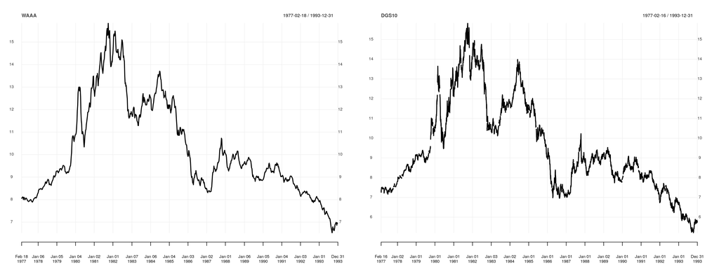

```r
par(mfrow=c(1,2))
par(mar=c(3,3,3,3))
Mytheme = chart_theme()
Mytheme$col$line.col = "black"
chart_Series(WAAA, theme = Mytheme)
chart_Series(DGS10, theme = Mytheme)
```

- Note that the series have different frequencies. `WAAA` is weekly, while `DGS10` is daily.

```r
dim(WAAA)
dim(DGS10)
```

1. 881

2. 1

1. 4403

2. 1

- We need to match the two first. The following code merge the two time series to have weekly frequency.

```r
dat <- merge(WAAA,DGS10)
dat <- na.locf(dat) # filling NA's with "last observation carried forward" rule
dat <- dat[index(WAAA)]
dim(dat)
head(dat)
```

1. 881

2. 2

```
           WAAA DGS10
1977-02-18 8.04  7.41
1977-02-25 8.08  7.48
1977-03-04 8.10  7.48
1977-03-11 8.12  7.44
1977-03-18 8.09  7.44
1977-03-25 8.00  7.48
```

- With the sample $\{(\text{WAAA}_n, \text{DGS10}_n)\}_{n=1}^{881}$ at hand, let us fit the line regression

  $\Delta \text{WAAA}_n = \beta_0 + \beta_1 \Delta \text{DGS10}_n + \eps_n$
- Here, $\Delta \text{WAAA}_n= \text{WAAA}_n - \text{WAAA}_{n-1}$ is the weekly corporate rate change. Similarly, $\Delta \text{DGS10}_n = \text{DGS10}_n - \text{DGS10}_{n-1}$ is the weekly treasury rate change.

```r
# Calculating the differences
AAA_dif = diff(as.vector(dat[,"WAAA"]))
DGS10_dif = diff(as.vector(dat[,"DGS10"]))
```

- Next, we fit the line regression model, using the R function `lm()`, and output the summary.
- The fitted line is

\begin{align*} \Delta \text{WAAA}_n = -0.000669 + 0.3232680\, \Delta \text{DGS10}_n + \eps_n \end{align*}

```r
# Fitting a linear model
fit1 <- lm(AAA_dif ~ DGS10_dif)
summary(fit1)
```

```
Call:
lm(formula = AAA_dif ~ DGS10_dif)

Residuals:
     Min       1Q   Median       3Q      Max
-0.52347 -0.04873  0.00102  0.05140  0.58795

Coefficients:
              Estimate Std. Error t value Pr(>|t|)
(Intercept) -0.0006696  0.0037821  -0.177     0.86
DGS10_dif    0.3232680  0.0182115  17.751   <2e-16 ***
---
Signif. codes:  0 ‘***’ 0.001 ‘**’ 0.01 ‘*’ 0.05 ‘.’ 0.1 ‘ ’ 1

Residual standard error: 0.1122 on 878 degrees of freedom
Multiple R-squared:  0.2641,	Adjusted R-squared:  0.2633
F-statistic: 315.1 on 1 and 878 DF,  p-value: < 2.2e-16
```

- We can then produce a simple scatter plot of the sample along with the regression line.

```r
# Setting parameters of the Jupyter notebook
sc = 1
options(repr.plot.width=6*sc,
        repr.plot.height=6*sc,
        repr.plot.pointsize = 20, # Text height in pt
        repr.plot.bg        = 'white',
        repr.plot.antialias = 'gray',
        #nice medium-res DPI
        repr.plot.res       = 70,
        #jpeg quality bumped from default
        repr.plot.quality   = 90,
        #vector font family
        repr.plot.family    = 'serif') # Vector font family. 'sans', 'serif', 'mono' or a specific one
par(mar=c(2,2,2,2))
```

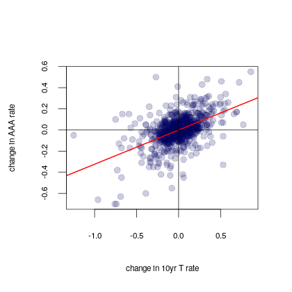

```r
plot(DGS10_dif,AAA_dif,xlab="change in 10yr T rate",
     ylab="change in AAA rate",pch=19,col=rgb(0,0,100,50,maxColorValue=255))
abline(fit1, col=2, lwd=2)
abline(h=0,v=0)
```

# 2. The variance of $\betah_1$

- Consider the line regression model:

  $Y_n = \beta_0 + \beta_1 X_n + \eps_n;\quad \text{ for } n = 1,2,\dots, N,$

  $~\eps_n\overset{i.i.d.}{\sim}N(0,\sig_\eps^2)$
- We showed that the LS estimates of the parameters are

  $\betah_1 = \sum_{n=1}^N\left(\frac{(X_n-\Xb)}{\sum_{n'=1}^N (X_{n'}-\Xb)^2}\right)Y_n = \frac{S_{XY}}{S_X^2},\quad\text{ and }\quad\betah_0 = \Yb - \betah_1 \Xb$

  where we have defined the sample averages $\Xb = \frac{\sum_{n=1}^N X_n}{N}$ and $\Yb = \frac{\sum_{n=1}^N Y_n}{N}$, the sample variance $S^2_X := \frac{\sum_{n=1}^N (X_n-\Xb)^2}{N-1}$, and the sample covariance $S_{XY} = \frac{\sum_{n=1}^N (Y_n - \Yb)(X_n-\Xb)}{N-1}$
- Q: How reliable are these estimates? How much error do they contain?
- Variance of an estimator is a good indicator of its error
- We can write $\betah_1 := \sum_{n=1}^N w_n Y_n$, where

\begin{align*} w_n:=\frac{X_n-\Xb}{\sum_{n'=1}^N(X_{n'}-\Xb)^2} \end{align*}

- Note that

\begin{align*} \sum_{n=1}^N w_n^2 = \sum_{n=1}^N\left(\frac{X_n-\Xb}{\sum_{n'=1}^N (X_{n'}-\Xb)^2}\right)^2= \frac{1}{\sum_{n'=1}^N(X_{n'}-\Xb)^2} = \frac{1}{(N-1)S_X^2} \end{align*}

- We then have:

\begin{align*} \Var\left(\betah_1|X_1,\dots,X_N\right) &= \Var\left(\sum_{n=1}^N w_n Y_n|X_1,\dots,X_N\right)\\ &=\sum_{n=1}^N w_n^2 \Var\left(Y_n|X_1,\dots,X_N\right) \quad\text{($Y_n$-s are uncorrelated | $X_n$-s)}\\ &=\sum_{n=1}^n w_n^2 \Var\left(\beta_0+\beta_1 X_n + \eps_n |X_1,\dots,X_N\right)\\ &=\sum_{n=1}^n w_n^2 \Var(\eps_n|X_1,\dots,X_N)\\ &=\sigma_\eps^2\sum_{n=1}^{N} w_n^2 = \frac{\sig_\eps^2}{(N-1)S_X^2} \end{align*}

- $\Var\left(\betah_1|X_1,\dots,X_n\right) = \frac{\sig_\eps^2}{(N-1)S_X^2}$
- Thus, the variance of $\betah_1$ is smaller (in other words, $\betah_1$ is a better estimator) if:
  - $\sig_\eps^2$ is smaller (less noise),
  - $N$ is larger (bigger sample), or
  - $S_X^2$ is larger (more variation in the observed predictor values).
- Using a similar argument, we can find the variance of $\betah_0$
- Many statistical softwares (such as R) calculate the variance of estimates (or their standard deviation)
- Consider the earlier example involving [10-year Treasury constant maturity rate](https://fred.stlouisfed.org/series/DGS10/) (symbol `DGS10`) and [Moody's seasoned corporate AAA yields](https://fred.stlouisfed.org/series/WAAA) (symbol `WAAA`), both of which are available from FRED

```r
fit <- lm(AAA_dif ~ DGS10_dif)
summary(fit)
```

```
Call:
lm(formula = AAA_dif ~ DGS10_dif)

Residuals:
     Min       1Q   Median       3Q      Max
-0.52347 -0.04873  0.00102  0.05140  0.58795

Coefficients:
              Estimate Std. Error t value Pr(>|t|)
(Intercept) -0.0006696  0.0037821  -0.177     0.86
DGS10_dif    0.3232680  0.0182115  17.751   <2e-16 ***
---
Signif. codes:  0 ‘***’ 0.001 ‘**’ 0.01 ‘*’ 0.05 ‘.’ 0.1 ‘ ’ 1

Residual standard error: 0.1122 on 878 degrees of freedom
Multiple R-squared:  0.2641,	Adjusted R-squared:  0.2633
F-statistic: 315.1 on 1 and 878 DF,  p-value: < 2.2e-16
```

- From the output on the next R output, we can see that the estimated model is

  $\Delta \text{WAAA}_n = -0.000669 + 0.3232680\, \Delta \text{DGS10}_n + \eps_n$

  The standard deviation of $\betah_0=-0.000669$ is $\sqrt{\Var(\betah_0)}=0.0037821$

  The standard deviation of $\betah_1=0.3232680$ is $\sqrt{\Var(\betah_1)}=0.0182115$

# 3. Multiple linear regression

- In a **multiple** regression model, we have several predictors $X_1$, $X_2$, ... , $X_p$
- We only have one response variable $Y$, however

  Regression models with many response variable are called **multivariate**
- We are given the following sample of N observations:

  1st observation: $X_{1,1}, \dots, X_{1,p}$, and $Y_1$

  2nd observation: $X_{2,1}, \dots, X_{2,p}$, and $Y_2$

  $\vdots$

  N-th observation: $X_{N,1}, \dots, X_{N,p}$, and $Y_N$
- The **multiple linear regression** model assumes that

  $Y_n = \beta_0 + \beta_1 X_{n,1} + \dots + \beta_p X_{n,p} + \eps_n;\quad n\in\{1,\dots,N\},$

  where $\beta_0,\dots,\beta_p$ are unknown parameters and $\eps_n\overset{i.i.d.}{\sim} N(0,\sig_\eps^2)$
- The LS estimators of $\beta_0,\dots,\beta_p$, denoted by $\betah_0,\dots,\betah_p$, are the minimizers of the following optimization problem

  $\displaystyle\betah_0,\dots,\betah_p = \underset{\beta_0,\dots,\beta_p\in\Rb}{\arg\min}\, f(\beta_0,\dots,\beta_p)$

  where the sum of squares error function $f$ is given by

  $\displaystyle f(b_0,\dots,b_p) := \sum_{n=1}^N \left(Y_n - b_0 - b_1 X_{n,1} - \dots - b_p X_{n,p}\right)^2$
- Using matrix notations simplifies the formulas. The N equations of the multiple linear regression model can be written in the matrix form

\begin{align*} \begin{pmatrix} Y_1\\ \vdots\\ Y_N \end{pmatrix} = \begin{pmatrix} 1 & X_{1,1} & \dots & X_{1,p}\\ \vdots\\ 1 & X_{N,1} & \dots & X_{N,p}\\ \end{pmatrix} \begin{pmatrix} \beta_0\\ \vdots\\ \beta_p \end{pmatrix} + \begin{pmatrix} \eps_1\\ \vdots\\ \eps_N \end{pmatrix} \end{align*}

- Let us define

\begin{align*} \Yv:= \begin{pmatrix} Y_1\\ \vdots\\ Y_N \end{pmatrix}, \quad \Xv:= \begin{pmatrix} 1 & X_{1,1} & \dots & X_{1,p}\\ \vdots\\ 1 & X_{N,1} & \dots & X_{N,p}\\ \end{pmatrix}, \quad \betav:= \begin{pmatrix} \beta_0\\ \vdots\\ \beta_p \end{pmatrix}, \quad\text{and}\quad\epsv:= \begin{pmatrix} \eps_1\\ \vdots\\ \eps_N \end{pmatrix}, \end{align*}

- Then, the multiple linear regression model becomes: $\Yv = \Xv\,\betav + \epsv$
- The sum of squared error function $f$ can be written in matrix form, as follows

\begin{align*} &f(\bv) = \|\Yv - \Xv\bv\|^2 \\ &=(\Yv - \Xv\bv)^\top(\Yv - \Xv\bv) = (\bv^\top\Xv^\top - \Yv^\top)(\Xv\bv - \Yv)\\ &= \bv^\top \Xv^\top \Xv \bv - 2 \Yv^\top \Xv \bv + \Yv\Yv^\top \end{align*}

\begin{align*} &= \bv^\top \Xv^\top \Xv\, \underbrace{(\Xv^\top \Xv)^{-1} \Xv^\top \Xv}\, \bv - 2 \Yv^\top \Xv \underbrace{(\Xv^\top \Xv)^{-1} \Xv^\top \Xv}\,\bv + \underbrace{\Yv^\top \Xv (\Xv^\top \Xv)^{-1} \Xv^\top \Yv}\\ &\qquad\underbrace{- \Yv^\top \Xv (\Xv^\top \Xv)^{-1} \Xv^\top \Yv} +\Yv\Yv^\top\\ &= \left(\Xv^\top \Xv\, \bv - \Xv^\top \Yv\right)^\top (\Xv^\top \Xv)^{-1} \left(\Xv^\top \Xv\, \bv- \Xv^\top \Yv\right) - \Yv^\top \Xv (\Xv^\top \Xv)^{-1} \Xv^\top \Yv +\Yv\Yv^\top \end{align*}

- Here, we assumed that the matrix $\Xv^\top \Xv$ is invertible. This assumption can be relaxed by using the **pseudoinverse** of $\Xv^\top \Xv$
- Since $\Xv^\top \Xv$ is positive definite, so is the matrix $(\Xv^\top \Xv)^{-1}$. Therefore, for all vectors $\bv$,

\begin{align*} \left(\Xv^\top \Xv\, \bv - \Xv^\top \Yv\right)^\top (\Xv^\top \Xv)^{-1} \left(\Xv^\top \Xv\, \bv - \Xv^\top \Yv\right)\ge 0 \end{align*}

- From the expression for $f(\bv)$, it then follows that the least square estimate $\betavh$ should satisfy

  $\Xv^\top \Xv\, \betavh - \Xv^\top \Yv = 0 \quad\Longrightarrow\quad \betavh = (\Xv^\top\Xv)^{-1}\Xv^\top \Yv$
- This is the formula for the LS estimators of the multiple linear regression model
- The n-th fitted value is

\begin{align*} \Yh_n = \betah_0 + \betah_1 X_{n,1} + \dots + \betah_p X_{n,p} \end{align*}

- Define the vector of fitted values as follows $\Yvh:=\begin{pmatrix}\Yh_1\\\vdots\\\Yh_N\end{pmatrix}$
- Then,

\begin{align*} \Yvh = \Xv \, \betavh = \Xv\, (\Xv^\top\Xv)^{-1}\Xv^\top \Yv =: H\,\Yv \end{align*}

- Here, the matrix $H := \Xv\, (\Xv^\top\Xv)^{-1}\Xv^\top$ is called the **"hat matrix"** (since it transforms $\Yv$ into $\Yvh$)
- Note that the hat matrix only depends on the values of the predictors $\Xv$
- We can also calculate the variances (and covariances) of $\betavh$

\begin{align*} \Cov\left(\betavh\middle|\Xv\right) &= \Cov\left((\Xv^\top\Xv)^{-1}\Xv^\top \Yv\middle|\Xv\right)\\ &= (\Xv^\top\Xv)^{-1}\Xv^\top\, \Cov\left( \Yv|X\right) \, \Xv (\Xv^\top\Xv)^{-1}\\ &= (\Xv^\top\Xv)^{-1}\Xv^\top\, \left(\sig_\eps^2\, \Iv\right) \, \Xv (\Xv^\top\Xv)^{-1} =\sig_\eps^2 (\Xv^\top\Xv)^{-1} \end{align*}

- Here, $\Iv$ is the identity matrix
- Thus, the variance of $\betah_k$ is the $k$-th diagonal element of $\sig_\eps^2 (\Xv^\top\Xv)^{-1}$

  and the covariance of $\betah_k$ and $\betah_\ell$ is the $k\ell$ element of $\sig_\eps^2 (\Xv^\top\Xv)^{-1}$
- The n-th residual is

\begin{align*} \epsh_n = Y_n - \Yh_n = Y_n - \betah_0 - \betah_1 X_{n,1} - \dots - \betah_p X_{n,p} \end{align*}

- It estimates the error $\eps_n$
- An **"unbiased estimator"** for $\sig_\eps^2$ is $\displaystyle\sigh_\eps^2 := \frac{\displaystyle\sum_{n=1}^N \epsh_n^2}{N-1-p}$

**Definition:** A random variable $X$ is an unbiased estimator of the parameter $p$ if $\Eb(X)=p$

- Let us fit a multiple linear regression model in R
- In addition to the [10-year Treasury constant maturity rate](https://fred.stlouisfed.org/series/DGS10) (symbol `DGS10`) and [Moody's seasoned corporate AAA yields](https://fred.stlouisfed.org/series/WAAA) (symbol `WAAA`), consider the [30-year Treasury constant maturity rates](https://fred.stlouisfed.org/series/DGS30) (symbol `DGS30`) and [Fedral funds rate](https://fred.stlouisfed.org/series/FF) (symbol `FF`), which are also available from FRED

```r
getSymbols(c("WAAA","DGS10","DGS30", "FF"), src="FRED")
dat <- na.locf(merge(WAAA,DGS10,DGS30,FF))[index(WAAA)]["1977-02-16/1993-12-31"]
```

1. 'WAAA'

2. 'DGS10'

3. 'DGS30'

4. 'FF'

```r
# Setting parameters of the Jupyter notebook
sc = .6
options(repr.plot.width=16*sc,
        repr.plot.height=6*sc,
        repr.plot.pointsize = 20, # Text height in pt
        repr.plot.bg        = 'white',
        repr.plot.antialias = 'gray',
        #nice medium-res DPI
        repr.plot.res       = 300,
        #jpeg quality bumped from default
        repr.plot.quality   = 90,
        #vector font family
        repr.plot.family    = 'serif') # Vector font family. 'sans', 'serif', 'mono' or a specific one
```

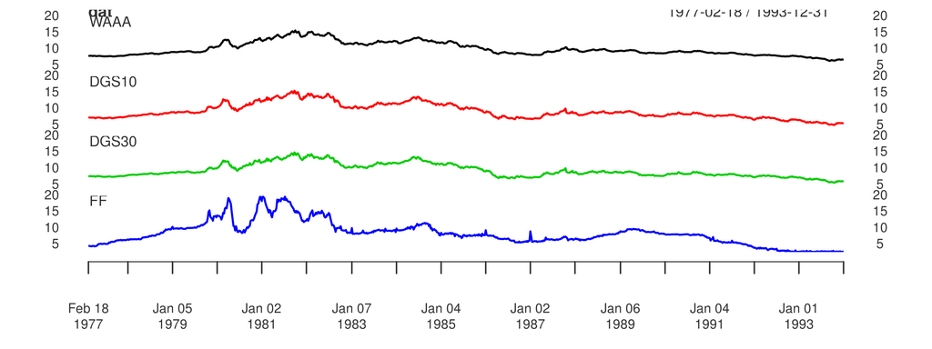

```r
plot(dat, multi.panel=4, grid.ticks.lwd=0)
```

- We would like to explain the change in `WAAA` by the change in the other three rates
- **Scatter plots** are good visual aids for detecting explanatory power of a predictor

```r
# Setting parameters of the Jupyter notebook
sc = .5
options(repr.plot.width=16*sc,
        repr.plot.height=6*sc,
        repr.plot.pointsize = 5, # Text height in pt
        repr.plot.bg        = 'white',
        repr.plot.antialias = 'gray',
        #nice medium-res DPI
        repr.plot.res       = 300,
        #jpeg quality bumped from default
        repr.plot.quality   = 90,
        #vector font family
        repr.plot.family    = 'serif') # Vector font family. 'sans', 'serif', 'mono' or a specific one
```

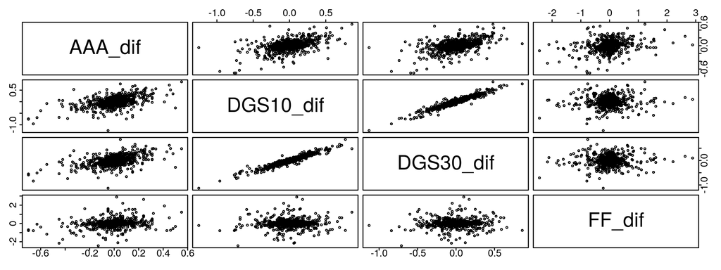

```r
AAA_dif = diff(as.vector(dat[,"WAAA"]))
DGS10_dif = diff(as.vector(dat[,"DGS10"]))
DGS30_dif = diff(as.vector(dat[,"DGS30"]))
FF_dif = diff(as.vector(dat[,"FF"]))

pairs(~AAA_dif+DGS10_dif+DGS30_dif+FF_dif)
```

- A **Correlation plot** can be used in place of the scatter plots

```r
install.packages("corrplot")
```

```r
# Setting parameters of the Jupyter notebook
sc = .75
options(repr.plot.width=13*sc,
        repr.plot.height=6*sc,
        repr.plot.pointsize = 5, # Text height in pt
        repr.plot.bg        = 'white',
        repr.plot.antialias = 'gray',
        #nice medium-res DPI
        repr.plot.res       = 300,
        #jpeg quality bumped from default
        repr.plot.quality   = 90,
        #vector font family
        repr.plot.family    = 'serif') # Vector font family. 'sans', 'serif', 'mono' or a specific one
```

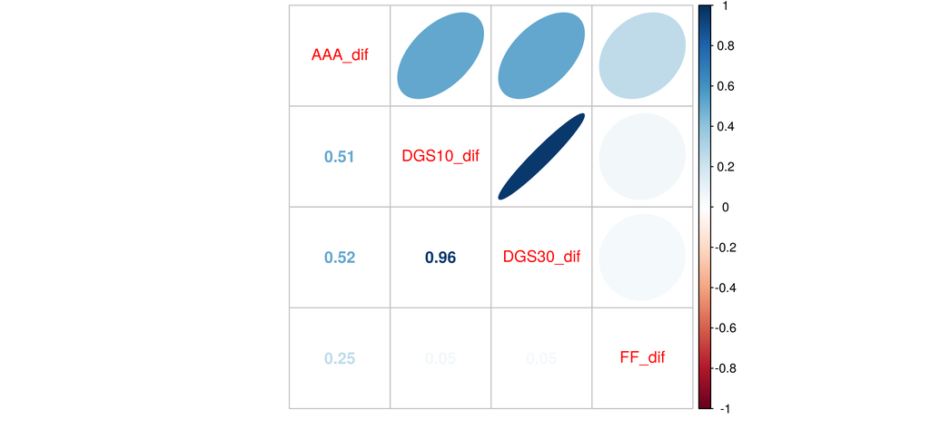

```r
rates <- data.frame(AAA_dif, DGS10_dif, DGS30_dif, FF_dif)
library(corrplot)
corrplot.mixed(cor(rates),upper="ellipse")
```

- Let us consider fitting the following multiple linear regression model

\begin{align*} \Delta \text{WAAA}_n = \beta_0 + \beta_1 \Delta \text{DGS10}_n + \beta_2 \Delta \text{DGS30}_n + \beta_3 \Delta \text{FF}_n + \eps_n \end{align*}

```r
fit <- lm(AAA_dif ~ DGS10_dif+DGS30_dif+FF_dif)
summary(fit)
```

```
Call:
lm(formula = AAA_dif ~ DGS10_dif + DGS30_dif + FF_dif)

Residuals:
     Min       1Q   Median       3Q      Max
-0.44083 -0.04746  0.00176  0.04788  0.61805

Coefficients:
              Estimate Std. Error t value Pr(>|t|)
(Intercept) -0.0005413  0.0036369  -0.149  0.88171
DGS10_dif    0.1298585  0.0627883   2.068  0.03891 *
DGS30_dif    0.2147151  0.0696579   3.082  0.00212 **
FF_dif       0.0676681  0.0084331   8.024 3.27e-15 ***
---
Signif. codes:  0 ‘***’ 0.001 ‘**’ 0.01 ‘*’ 0.05 ‘.’ 0.1 ‘ ’ 1

Residual standard error: 0.1079 on 876 degrees of freedom
Multiple R-squared:  0.3211,	Adjusted R-squared:  0.3188
F-statistic: 138.1 on 3 and 876 DF,  p-value: < 2.2e-16
```

- We obtain the following model

\begin{align*} &\Delta \text{WAAA}_n = -0.0005413 + 0.1298585\, \Delta \text{DGS10}_n + 0.2147151 \,\Delta \text{DGS30}_n\\ &\qquad\qquad\qquad+ 0.0676681\, \Delta \text{FF}_n + \eps_n\\ &\eps_n\overset{i.i.d.}{\sim} N(0, 0.1079^2) \end{align*}

# 4. Review of hypothesis testing

- Next, we briefly go over statistical inference (hypothesis testing)
- See Appendix A.18 of the textbook for more information
- Statistical hypothesis testing is a framework by which one uses data to decide if a statement, called the "null hypothesis" and denoted by $H_0$, is true or not
- The negation of the null hypothesis is called the "alternative hypothesis" and is denoted by $H_1$

**Example:**

- We want to test if a random variable $Y$ has a linear dependence on another random variable $X$
- we draw a sample $(X_1,Y_1), \dots, (X_N, Y_N)$ and consider the regression model $Y_n = \beta_0 + \beta_1 X_n + \eps_n$
- To test for linear dependence, we consider the null hypothesis of $\beta_1=0$ versus the alternative hypothesis $\beta_1\ne0$
- This test is usually represented as follows

\begin{align*} \begin{cases} H_0: \beta_1=0,\\ H_1: \beta_1\ne0. \end{cases} \end{align*}

- There are two approaches to conduct statistical tests: using **test statistics** or using **p-values**
- A test statistic is an appropriate random variable that depends on the sample of observations. The choice of the test statistic depends on the type of test under consideration
- **"Rejection region"** is a range of possible values of the test statistic
- If the test statistic falls inside the rejection region, we reject $H_0$. Otherwise, we accept $H_0$
- The rejection region is chosen to control the probability of the **"type I error"** of the test.

  Type I error: rejecting $H_0$ when it is true
- The "significance level" (or simply the level) of a test is the probability of its type I error, that is

\begin{align*} \text{significance level} = \Pb\left(\text{test statistic in the rejection region}|H_0\right) \end{align*}

**Example:**

- For the previous test, one suitable test statistic is $\displaystyle T = \frac{\betah_1}{\sqrt{\sigh_{\beta_1}^2}}$

  where $\displaystyle\sigh_{\beta_1}^2 = \frac{\sigh_\eps^2}{(N-1)S_X^2}$
- It can be shown that if $H_0: \beta_1=0$ is correct, then T has a t-distribution with $N-p-1$ degrees of freedom
- The rejection region for this test is $(-\infty, -x)\cup(x,+\infty)$, where the value of $x$ determines the significance level of the test
- In particular, let $\al$ be the significance level. Then, by the symmetry of the t-distribution, we have

  $\displaystyle\al = \Pb\left(|T|>x\right) \Longrightarrow \Pb\left(T<-x\right)=\frac{\al}{2}$
- In other words, $-x$ is $q_{\frac{\al}{2}}$, the $\frac{\al}{2}$-th quantile of the t-distribution with $N-p-1$ degree of freedom
- Thus, the rejection region for a significance level of $\al$ is $(-\infty, q_{\frac{\al}{2}})\cup(-q_{\frac{\al}{2}},+\infty)$
- Note that we need to find a new rejection region if we change the significance level, this is inconvenient
- By using **p-values**, we can conduct statistical test for any level
- The p-value corresponding to an observed value of a test statistic is the smallest significance level under which $H_0$ is rejected, assuming that $H_0$ is actually true
- Intuitively, p-value measures the likelihood of $H_0$ given the observed value of the test statistic
- P-values near zero indicates that the value of the test statistic is in favor of $H_1$. P-values near one are in favor of the $H_0$
- To use p-value for conducting a test, simply compare it with the significance level $\al$. If p-value $\le \al$, then reject $H_0$. If p-value $> \al$ then accept $H_0$
- The advantage of using p-values, instead of the test statistic and rejection region, is that one can repeat a test with different significance level without doing extra calculation for obtaining the rejection region

**Example:** In the previous example, the p-value for an observed value $t$ of the test statistic $T$ is

$\text{p-value}(t) = \Pb\left(|T|\ge t| H_0\right) = 2 \Pb\big(T<-|t|\,\big|\,H_0\big)$

# 4.1. Basic statistics and t-test for regression models

- R reports 3 statistics for each estimate of the regression coefficients $\betah_0, \dots, \betah_p$:
  1. The standard error (SE) - An estimation of the standard deviation of $\betah_i$, indicates the precision of the estimator
  2. t-value - the t-test statistic for the null hypothesis $H_0: \beta_i=0$
  3. p-value corresponding to observed value of the t-test statistic

```r
fit <- lm(AAA_dif ~ DGS10_dif+DGS30_dif+FF_dif)
summary(fit)
```

```
Call:
lm(formula = AAA_dif ~ DGS10_dif + DGS30_dif + FF_dif)

Residuals:
     Min       1Q   Median       3Q      Max
-0.44083 -0.04746  0.00176  0.04788  0.61805

Coefficients:
              Estimate Std. Error t value Pr(>|t|)
(Intercept) -0.0005413  0.0036369  -0.149  0.88171
DGS10_dif    0.1298585  0.0627883   2.068  0.03891 *
DGS30_dif    0.2147151  0.0696579   3.082  0.00212 **
FF_dif       0.0676681  0.0084331   8.024 3.27e-15 ***
---
Signif. codes:  0 ‘***’ 0.001 ‘**’ 0.01 ‘*’ 0.05 ‘.’ 0.1 ‘ ’ 1

Residual standard error: 0.1079 on 876 degrees of freedom
Multiple R-squared:  0.3211,	Adjusted R-squared:  0.3188
F-statistic: 138.1 on 3 and 876 DF,  p-value: < 2.2e-16
```